# 30-Day Mortality Rate of Cardiac Arrest Patients Admitted to CCU

Nan Liu

# Introduction

In this research, we use MIMIC-III data set. MIMIC-III (Medical Information Mart for Intensive Care III) is a database comprising deidentified health-related data associated with over forty thousand patients who stayed in critical care units of the Beth Israel Deaconess Medical Center between 2001 and 2012.The database provides information such as demographics, vital sign measurements made at the bedside, laboratory test results, procedures, medications, caregiver notes, imaging reports, and mortality (both in and out of hospital).

This report focus on the analysis of mortality rate of cardiac arrest 30 days after discharge from hospital.

# Data preparation

## Connect to PostgresSQL database

Load database libraries and the tidyverse frontend:

```r
library(DBI)
library(RPostgreSQL)
library(tidyverse)
library(lubridate)
```

Credentials for using PostgreSQL database. We are going to use username `postgres` with password `postgres` to access the `mimic` database in the schemee `mimiciii`.

```r
# Load configuration settings
dbdriver <- 'PostgreSQL'
user  <- 'postgres'
password <- 'postgres'
dbname <- 'mimic'
schema <- 'mimiciii'
# Connect to the database using the configuration settings
con <- dbConnect(RPostgreSQL::PostgreSQL(),
                 dbname = dbname,
                 user = user,
                 password = password)
# Set the default schema
dbExecute(con, paste("SET search_path TO ", schema, sep =" "))
```

```
## [1] 0
```

```r
con
```

```
## <PostgreSQLConnection>
```

```r
#lapply(dbListConnections(PostgreSQL()), dbDisconnect)
```

## Query and subsetting

Create a cohort of patients who were directly admitted into CCU and were diagnosed with cardiac arrest.

First we create a (query) table of patients who were directly admitted into CCU.

```r
tbl(con, "transfers") %>%
  select(subject_id, hadm_id, prev_careunit, curr_careunit) %>%
  filter(is.na(prev_careunit) & curr_careunit == "CCU") %>%
  select(subject_id, hadm_id) %>%
  distinct() %>%
  print() -> ccu_admissions
```

```
## # Source:   lazy query [?? x 2]
## # Database: postgres 11.0.7 [postgres@/var/run/postgresql:5432/mimic]
##    subject_id hadm_id
##         <int>   <int>
##  1      42525  142743
##  2      23028  190183
##  3      24357  111518
##  4      23872  120477
##  5       9768  128541
##  6      23474  128369
##  7      30292  113876
##  8      19848  167716
##  9      12138  131429
## 10      10616  122738
## # … with more rows
```

Now we want to restrict to cardiac arrest patients. To find all possible ICD-9 codes related to cardiac arrest, we search for string `cardiac arrest` in the `long_title` of table `d_icd_diagnoses`:

```r
tbl(con, "d_icd_diagnoses") %>%
  filter(str_detect(tolower(long_title), "cardiac arrest")) %>% #ignore upper lower letter
  print() -> ca_codes
```

```
## # Source:   lazy query [?? x 4]
## # Database: postgres 11.0.7 [postgres@/var/run/postgresql:5432/mimic]
##   row_id icd9_code short_title             long_title
##    <int> <chr>     <chr>                   <chr>
## 1   4466 4275      Cardiac arrest          Cardiac arrest
## 2   8956 77985     NB cardiac arrest       Cardiac arrest of newborn
## 3  13947 V1253     Hx sudden cardiac arre… Personal history of sudden cardiac a…
```

`diagnoses_icd` table stores the diagnosis of each admission. We use `semi_join()` to keep the rows in `diagnoses_icd` that match the ICD-9 codes related to cardiac arrest:

```r
tbl(con, "diagnoses_icd") %>%
  semi_join(ca_codes, by = "icd9_code") %>%
  print() -> ca_admissions
```

```
## # Source:   lazy query [?? x 5]
## # Database: postgres 11.0.7 [postgres@/var/run/postgresql:5432/mimic]
##    row_id subject_id hadm_id seq_num icd9_code
##     <int>      <int>   <int>   <int> <chr>
##  1    798        101  175533       6 4275
##  2    822        103  133550       4 4275
##  3      7          3  145834       4 4275
##  4     57         12  112213       4 4275
##  5   2417        194  124794       5 4275
##  6   2048        164  182743       4 4275
##  7   1838        146  190707       3 4275
##  8   1383        109  189332      10 4275
##  9   1463        111  155897      12 4275
## 10    854        106  145167       7 4275
## # … with more rows
```

```r
ca_admissions %>%
  filter(seq_num <= 5) %>%
  group_by(subject_id, hadm_id) %>%
  filter(min_rank(seq_num) <= 1) %>%
  ungroup() %>%
  select(subject_id, hadm_id, icd9_code, seq_num) %>%
  print() -> ca_admissions
```

```
## # Source:   lazy query [?? x 4]
## # Database: postgres 11.0.7 [postgres@/var/run/postgresql:5432/mimic]
##    subject_id hadm_id icd9_code seq_num
##         <int>   <int> <chr>       <int>
##  1          3  145834 4275            4
##  2         12  112213 4275            4
##  3        103  133550 4275            4
##  4        146  190707 4275            3
##  5        164  182743 4275            4
##  6        194  124794 4275            5
##  7        201  161473 4275            5
##  8        268  110404 4275            5
##  9        330  197569 4275            4
## 10        344  176203 4275            5
## # … with more rows
```

Now we `inner_join` the table of admissions to CCU and the table of admissions that include CA diagnosis.

```r
ccu_admissions %>%
  inner_join(ca_admissions, by = c("subject_id", "hadm_id")) %>%
  print() -> study_admissions
```

```
## # Source:   lazy query [?? x 4]
## # Database: postgres 11.0.7 [postgres@/var/run/postgresql:5432/mimic]
##    subject_id hadm_id icd9_code seq_num
##         <int>   <int> <chr>       <int>
##  1        146  190707 4275            3
##  2        194  124794 4275            5
##  3        404  166989 4275            2
##  4        456  113035 4275            2
##  5        491  157083 4275            4
##  6        543  115307 4275            2
##  7        669  109338 4275            4
##  8        710  114242 4275            3
##  9        738  101840 4275            4
## 10        931  141560 4275            5
## # … with more rows
```

## Transform and augment query tables

Now we create a logical variable indicating the CA is the principal diagonosis or not (according to `seq_num`).

```r
study_admissions %>%
  mutate(principal_dx = seq_num == 1) %>%
  select(-seq_num) %>%
  print() -> study_admissions
```

```
## # Source:   lazy query [?? x 4]
## # Database: postgres 11.0.7 [postgres@/var/run/postgresql:5432/mimic]
##    subject_id hadm_id icd9_code principal_dx
##         <int>   <int> <chr>     <lgl>
##  1        146  190707 4275      FALSE
##  2        194  124794 4275      FALSE
##  3        404  166989 4275      FALSE
##  4        456  113035 4275      FALSE
##  5        491  157083 4275      FALSE
##  6        543  115307 4275      FALSE
##  7        669  109338 4275      FALSE
##  8        710  114242 4275      FALSE
##  9        738  101840 4275      FALSE
## 10        931  141560 4275      FALSE
## # … with more rows
```

We want to add information about the severity of patients’ ailments. The `drgcodes` table contains, for `DRG` codes from the All Payers Registry (APR), severity and mortality indicators. We pull the drug severity information and right-join it to our query table.

```r
tbl(con, "drgcodes") %>%
  filter(str_detect(drg_type, "APR")) %>%
  select(subject_id, hadm_id, drg_severity) %>%
  right_join(study_admissions, by = c("subject_id", "hadm_id")) %>%
  mutate(drg_severity = ifelse(is.na(drg_severity), 1, drg_severity)) %>%
  group_by(subject_id, hadm_id) %>%
  summarise (drg_severity = mean(drg_severity, na.rm = TRUE)) %>%
  print() -> study_admissions
```

```
## # Source:   lazy query [?? x 3]
## # Database: postgres 11.0.7 [postgres@/var/run/postgresql:5432/mimic]
## # Groups:   subject_id
##    subject_id hadm_id drg_severity
##         <int>   <int>        <dbl>
##  1        146  190707            1
##  2        194  124794            1
##  3        404  166989            4
##  4        456  113035            1
##  5        491  157083            1
##  6        543  115307            3
##  7        669  109338            1
##  8        710  114242            1
##  9        738  101840            1
## 10        931  141560            1
## # … with more rows
```

Pull the admission time `admittime`, discharge time `dischtime`, date of birth `dob`, and date of death `dod`. We are interested in the mortaility rate 30 days after discharge. So we only keep patients who didn’t die in hospital.

```r
study_admissions %>%
  left_join(
    select(tbl(con, "admissions"),
           subject_id, hadm_id, admittime, dischtime, hospital_expire_flag
    ), by = c("subject_id","hadm_id")
  ) %>%
  filter(hospital_expire_flag == 0) %>% # patients who did not die in hospital
  select(-hospital_expire_flag) %>%
  left_join(
    select(tbl(con, "patients"), subject_id, dob, dod),
    by = "subject_id"
  ) %>%
  print(width = Inf) -> study_admissions
```

```
## # Source:   lazy query [?? x 7]
## # Database: postgres 11.0.7 [postgres@/var/run/postgresql:5432/mimic]
## # Groups:   subject_id
##    subject_id hadm_id drg_severity admittime           dischtime
##         <int>   <int>        <dbl> <dttm>              <dttm>
##  1        146  190707            1 2119-12-19 12:15:00 2120-01-10 13:08:00
##  2        194  124794            1 2112-05-23 10:27:00 2112-05-26 18:43:00
##  3        456  113035            1 2197-11-16 12:22:00 2197-11-22 14:22:00
##  4        543  115307            3 2148-12-13 19:40:00 2148-12-18 19:50:00
##  5        738  101840            1 2188-09-06 01:31:00 2188-09-12 11:45:00
##  6       1359  108736            1 2126-05-20 12:05:00 2126-05-23 15:55:00
##  7       1777  180610            1 2125-07-15 18:38:00 2125-07-26 14:14:00
##  8       1970  144456            4 2164-09-04 05:30:00 2164-10-09 13:16:00
##  9       2237  142708            1 2128-04-26 15:18:00 2128-05-12 16:28:00
## 10       2280  146949            1 2133-10-26 20:43:00 2134-01-22 17:15:00
##    dob                 dod
##    <dttm>              <dttm>
##  1 2034-05-31 00:00:00 2124-12-30 00:00:00
##  2 2065-03-29 00:00:00 NA
##  3 2150-07-30 00:00:00 NA
##  4 2096-09-27 00:00:00 NA
##  5 2126-11-06 00:00:00 NA
##  6 2049-03-11 00:00:00 NA
##  7 2060-04-04 00:00:00 NA
##  8 2123-11-10 00:00:00 NA
##  9 2049-09-22 00:00:00 NA
## 10 2079-04-27 00:00:00 NA
## # … with more rows
```

To add `age` (at admission) variable into the table. [The documentation for the patients table](https://mimic.physionet.org/mimictables/patients/) explains that patients of 90 years and older had their ages artificially inflated, so we remove these patients from the analysis. Also create new variable `death` to indicate whether the patient dies or not in 30 days.

```r
study_admissions %>%
  mutate(dyear = date_part("year", dod) - date_part("year", dischtime)) %>%
  mutate(dmonth = date_part("month", dod) - date_part("month", dischtime)) %>%
  mutate(dday = date_part("day", dod) - date_part("day", dischtime)) %>%
  mutate(death = ifelse(
  (dyear == 0) & (dmonth <= 1) & (dday <= 0) |
    (
     (dyear == 0) & (dmonth == 0) & (dday >= 0)
    ),
  1,
  NA
)) %>%

  mutate(age = date_part("year", admittime) - date_part("year", dob)) %>%
  filter(age < 90) %>%
  mutate(age = age - ifelse(
    date_part("month", admittime) < date_part("month", dob) |
      (
        date_part("month", admittime) == date_part("month", dob) &
          date_part("day", admittime) < date_part("day", dob)
      ),
    1,
    0
  )) %>%
  select(-admittime, -dischtime, -dob, -dod, -dyear, -dmonth, -dday) %>%
  select(subject_id, hadm_id, age, death, everything()) %>%
  print() -> study_admissions
```

```
## # Source:   lazy query [?? x 5]
## # Database: postgres 11.0.7 [postgres@/var/run/postgresql:5432/mimic]
## # Groups:   subject_id
##    subject_id hadm_id   age death drg_severity
##         <int>   <int> <dbl> <dbl>        <dbl>
##  1        146  190707    85    NA            1
##  2        194  124794    47    NA            1
##  3        456  113035    47    NA            1
##  4        543  115307    52    NA            3
##  5        738  101840    61    NA            1
##  6       1359  108736    77    NA            1
##  7       1777  180610    65    NA            1
##  8       1970  144456    40    NA            4
##  9       2237  142708    78    NA            1
## 10       2280  146949    54    NA            1
## # … with more rows
```

To add `admission_location` variable into the table:

```r
tbl(con, "admissions") %>%
  select(subject_id, hadm_id, admission_location) %>%
  right_join(study_admissions, by = c("subject_id", "hadm_id")) %>%
  print() -> study_admissions
```

```
## # Source:   lazy query [?? x 6]
## # Database: postgres 11.0.7 [postgres@/var/run/postgresql:5432/mimic]
##    subject_id hadm_id admission_location          age death drg_severity
##         <int>   <int> <chr>                     <dbl> <dbl>        <dbl>
##  1        146  190707 TRANSFER FROM HOSP/EXTRAM    85    NA            1
##  2        194  124794 TRANSFER FROM HOSP/EXTRAM    47    NA            1
##  3        456  113035 TRANSFER FROM HOSP/EXTRAM    47    NA            1
##  4        543  115307 TRANSFER FROM HOSP/EXTRAM    52    NA            3
##  5        738  101840 EMERGENCY ROOM ADMIT         61    NA            1
##  6       1359  108736 EMERGENCY ROOM ADMIT         77    NA            1
##  7       1777  180610 TRANSFER FROM HOSP/EXTRAM    65    NA            1
##  8       1970  144456 TRANSFER FROM HOSP/EXTRAM    40    NA            4
##  9       2237  142708 EMERGENCY ROOM ADMIT         78    NA            1
## 10       2280  146949 EMERGENCY ROOM ADMIT         54    NA            1
## # … with more rows
```

Many mortality indicators are missing, due to neither the hospital database nor the social security database having a record of these patients’ deaths. We could convert these to `FALSE` values, but it may be helpful to retain in the analytic table this information on whether deaths were recorded at all, e.g. for validation or sensitivity testing.

Finally, let’s merge some demographic information (ethnicity, gender) into our study `study_admissions`.

```r
tbl(con, "admissions") %>%
  select(subject_id, ethnicity) %>%
  distinct() %>%
  print() -> study_subjects
```

```
## # Source:   lazy query [?? x 2]
## # Database: postgres 11.0.7 [postgres@/var/run/postgresql:5432/mimic]
##    subject_id ethnicity
##         <int> <chr>
##  1       1421 BLACK/AFRICAN AMERICAN
##  2      68255 ASIAN
##  3       4901 WHITE
##  4      81232 WHITE
##  5      28292 WHITE
##  6      21741 WHITE
##  7      12175 BLACK/AFRICAN AMERICAN
##  8        341 BLACK/AFRICAN AMERICAN
##  9      48629 UNABLE TO OBTAIN
## 10      18688 HISPANIC OR LATINO
## # … with more rows
```

```r
tbl(con, "patients") %>%
  select(subject_id, gender) %>%
  distinct() %>%
  full_join(study_subjects, by = "subject_id") %>%
  print() -> study_subjects
```

```
## # Source:   lazy query [?? x 3]
## # Database: postgres 11.0.7 [postgres@/var/run/postgresql:5432/mimic]
##    subject_id gender ethnicity
##         <int> <chr>  <chr>
##  1      26121 M      WHITE
##  2       7489 F      WHITE
##  3      81661 M      WHITE
##  4      30273 F      WHITE
##  5      55935 F      BLACK/AFRICAN AMERICAN
##  6      63914 M      UNABLE TO OBTAIN
##  7      19393 M      WHITE
##  8      15861 M      WHITE
##  9      12289 F      WHITE
## 10      31927 F      PORTUGUESE
## # … with more rows
```

```r
study_subjects %>%
  semi_join(study_admissions, by = "subject_id") %>%
  print() -> study_subjects
```

```
## # Source:   lazy query [?? x 3]
## # Database: postgres 11.0.7 [postgres@/var/run/postgresql:5432/mimic]
##    subject_id gender ethnicity
##         <int> <chr>  <chr>
##  1      27382 F      WHITE
##  2      27540 M      WHITE
##  3      14584 M      WHITE
##  4      57321 M      ASIAN - CHINESE
##  5      68299 M      WHITE
##  6      54675 F      WHITE
##  7      50221 M      WHITE
##  8      50362 M      WHITE
##  9      28364 M      WHITE
## 10      17652 M      WHITE
## # … with more rows
```

Let’s resolves ome diversity and inconsistency in the `ethnicity` field:

```r
unknown_ethnicity <- c(
  "OTHER",
  "UNABLE TO OBTAIN",
  "UNKNOWN/NOT SPECIFIED",
  "MULTI RACE ETHNICITY",
  "PATIENT DECLINED TO ANSWER",
  "UNKNOWN"
)

study_subjects %>%
  collect() %>%
  mutate(ethnic_group = case_when(
    str_detect(ethnicity, "^ASIAN") ~ "ASIAN",
    str_detect(ethnicity, "^BLACK") ~ "BLACK",
    str_detect(ethnicity, "^HISPANIC") ~ "HISPANIC",
    str_detect(ethnicity, "^WHITE") ~ "WHITE",
    ethnicity %in% unknown_ethnicity ~ NA_character_,
    TRUE ~ NA_character_
  )) %>%
  select(subject_id, gender, ethnic_group) %>%
  print() -> study_subjects
```

```
## # A tibble: 190 x 3
##    subject_id gender ethnic_group
##         <int> <chr>  <chr>
##  1        146 M      <NA>
##  2        194 M      BLACK
##  3        456 M      <NA>
##  4        543 M      WHITE
##  5        738 M      WHITE
##  6       1359 M      WHITE
##  7       1777 F      WHITE
##  8       1970 M      WHITE
##  9       2237 F      WHITE
## 10       2280 M      ASIAN
## # … with 180 more rows
```

Some patients are coded as belonging to more than one ethnic group. To resolve these inconsistencies, we define a helper function to pick the modal value from a vector of values in R, which can be used by the `summarize()` function to choose one ethnic group for each patient.

```r
most <- function(x) {
  if (all(is.na(x))) return(NA_character_)
  y <- table(x, useNA = "no")
  if (length(which(y == max(y))) > 1) return(NA_character_)
  return(names(y)[which.max(y)])
}

study_subjects %>%
  group_by(subject_id) %>%
  summarize(ethnic_group = most(ethnic_group)) %>%
  ungroup() %>%
  mutate(ethnic_group = ifelse(is.na(ethnic_group), "UNKNOWN", ethnic_group)) %>%
  print() -> subject_ethnic_groups
```

```
## # A tibble: 185 x 2
##    subject_id ethnic_group
##         <int> <chr>
##  1        146 UNKNOWN
##  2        194 BLACK
##  3        456 UNKNOWN
##  4        543 WHITE
##  5        738 WHITE
##  6       1359 WHITE
##  7       1777 WHITE
##  8       1970 WHITE
##  9       2237 WHITE
## 10       2280 ASIAN
## # … with 175 more rows
```

```r
study_subjects %>%
  select(subject_id, gender) %>%
  left_join(subject_ethnic_groups, by = "subject_id") %>%
  distinct() %>%
  print() -> study_subjects
```

```
## # A tibble: 185 x 3
##    subject_id gender ethnic_group
##         <int> <chr>  <chr>
##  1        146 M      UNKNOWN
##  2        194 M      BLACK
##  3        456 M      UNKNOWN
##  4        543 M      WHITE
##  5        738 M      WHITE
##  6       1359 M      WHITE
##  7       1777 F      WHITE
##  8       1970 M      WHITE
##  9       2237 F      WHITE
## 10       2280 M      ASIAN
## # … with 175 more rows
```

Now we add the demographic information `gender` and `ethnicity` into our `study_admissions` table:

```r
study_admissions %>%
  left_join(study_subjects,  by = "subject_id", copy = TRUE) %>%
  distinct() %>%
  print -> study_admissions
```

```
## # Source:   lazy query [?? x 8]
## # Database: postgres 11.0.7 [postgres@/var/run/postgresql:5432/mimic]
##    subject_id hadm_id admission_locat…   age death drg_severity gender
##         <int>   <int> <chr>            <dbl> <dbl>        <dbl> <chr>
##  1        146  190707 TRANSFER FROM H…    85    NA            1 M
##  2        194  124794 TRANSFER FROM H…    47    NA            1 M
##  3        456  113035 TRANSFER FROM H…    47    NA            1 M
##  4        543  115307 TRANSFER FROM H…    52    NA            3 M
##  5        738  101840 EMERGENCY ROOM …    61    NA            1 M
##  6       1359  108736 EMERGENCY ROOM …    77    NA            1 M
##  7       1777  180610 TRANSFER FROM H…    65    NA            1 F
##  8       1970  144456 TRANSFER FROM H…    40    NA            4 M
##  9       2237  142708 EMERGENCY ROOM …    78    NA            1 F
## 10       2280  146949 EMERGENCY ROOM …    54    NA            1 M
## # … with more rows, and 1 more variable: ethnic_group <chr>
```

## Study cohort

CONSORT Flow Diagrams can be used to plot the flow of data selection of a patient cohort.

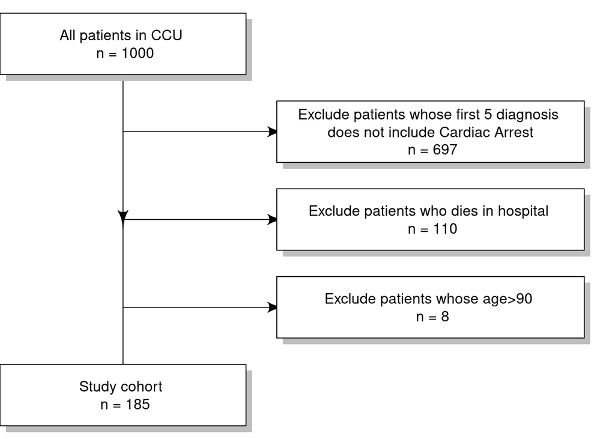

```r
library(shape)
library(diagram)

# set margins and multiplot
par(mfrow = c(1, 1))
par(mar = c(0, 0, 0, 0))

# initialise a plot device
openplotmat()

# position of boxes
# 1st column indicates x axis position between 0 and 1
# 2nd column indicates y axis position between 0 and 1
# automatically assigns vertical position
num_of_boxes <- 5
auto_coords = coordinates(num_of_boxes)
vert_pos = rev(auto_coords[,1])
box_pos <- matrix(nrow = num_of_boxes, ncol = 2, data = 0)
box_pos[1,] = c(0.20, vert_pos[1]) # 1st box
box_pos[2,] = c(0.70, vert_pos[2]) # 2nd box
box_pos[3,] = c(0.70, vert_pos[3]) # 3rd box
box_pos[4,] = c(0.70, vert_pos[4]) # 4th box
box_pos[5,] = c(0.20, vert_pos[5]) # 5th box

# content of boxes
box_content <- matrix(nrow = num_of_boxes, ncol = 1, data = 0)
box_content[1] = "All patients in CCU \n n = 1000" # 1st box
box_content[2] = "Exclude patients whose first 5 diagnosis \n does not include Cardiac Arrest \n n = 697" # 2nd box
box_content[3] = "Exclude patients who dies in hospital \n n = 110" # 3rd box
box_content[4] = "Exclude patients whose age>90 \n n = 8" # etc...
box_content[5] = "Study cohort \n n = 185"

# adjust the size of boxes to fit content
box_x <- c(0.20, 0.25, 0.25, 0.25, 0.20)
box_y <- c(0.07, 0.07, 0.07, 0.07, 0.07)

# Draw the arrows
straightarrow(from = c(box_pos[1,1],box_pos[2,2]), to = box_pos[2,], lwd = 1)
straightarrow(from = c(box_pos[1,1],box_pos[3,2]), to = box_pos[3,], lwd = 1)
straightarrow(from = c(box_pos[1,1],box_pos[4,2]), to = box_pos[4,], lwd = 1)
straightarrow(from = box_pos[1,], to = box_pos[5,], lwd = 1)

# Draw the boxes
for (i in 1:num_of_boxes) {
  textrect(mid = box_pos[i,], radx = box_x[i], rady = box_y[i],
           lab = box_content[i],
           shadow.col = "grey")
  }
```

# Data Visualization

```r
head(study_admissions)
```

```
## # Source:   lazy query [?? x 8]
## # Database: postgres 11.0.7 [postgres@/var/run/postgresql:5432/mimic]
##   subject_id hadm_id admission_locat…   age death drg_severity gender
##        <int>   <int> <chr>            <dbl> <dbl>        <dbl> <chr>
## 1        146  190707 TRANSFER FROM H…    85    NA            1 M
## 2        194  124794 TRANSFER FROM H…    47    NA            1 M
## 3        456  113035 TRANSFER FROM H…    47    NA            1 M
## 4        543  115307 TRANSFER FROM H…    52    NA            3 M
## 5        738  101840 EMERGENCY ROOM …    61    NA            1 M
## 6       1359  108736 EMERGENCY ROOM …    77    NA            1 M
## # … with 1 more variable: ethnic_group <chr>
```

## Bar plot of mortality

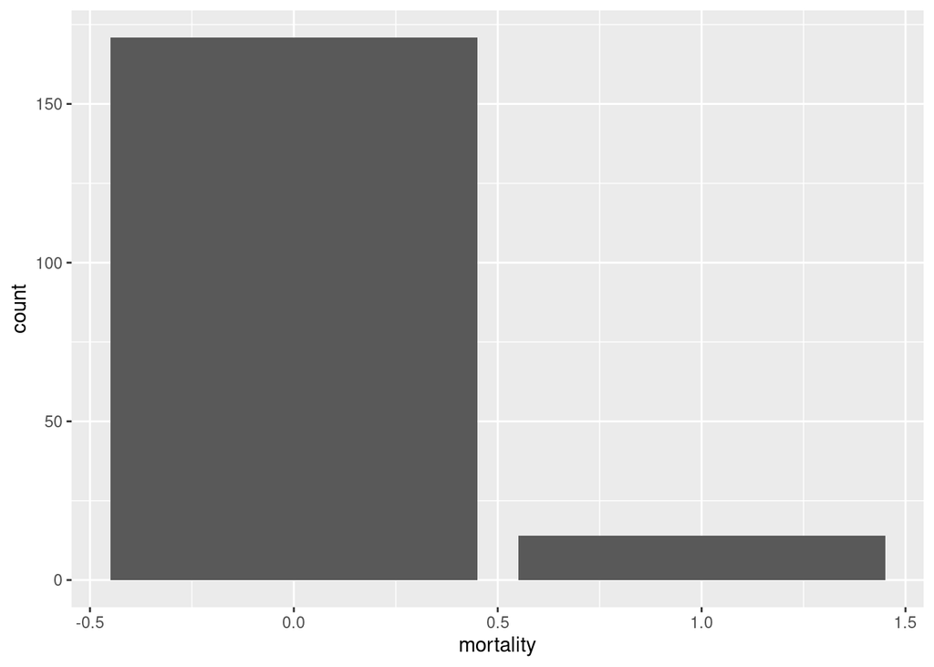

```r
study_admissions %>%
   mutate(livedeath =ifelse(is.na(death) == FALSE, 1, 0)) %>%
   ggplot() +
   geom_bar(mapping = aes(x = livedeath)) +
   labs(x = "mortality")
```

## Bar plot of age

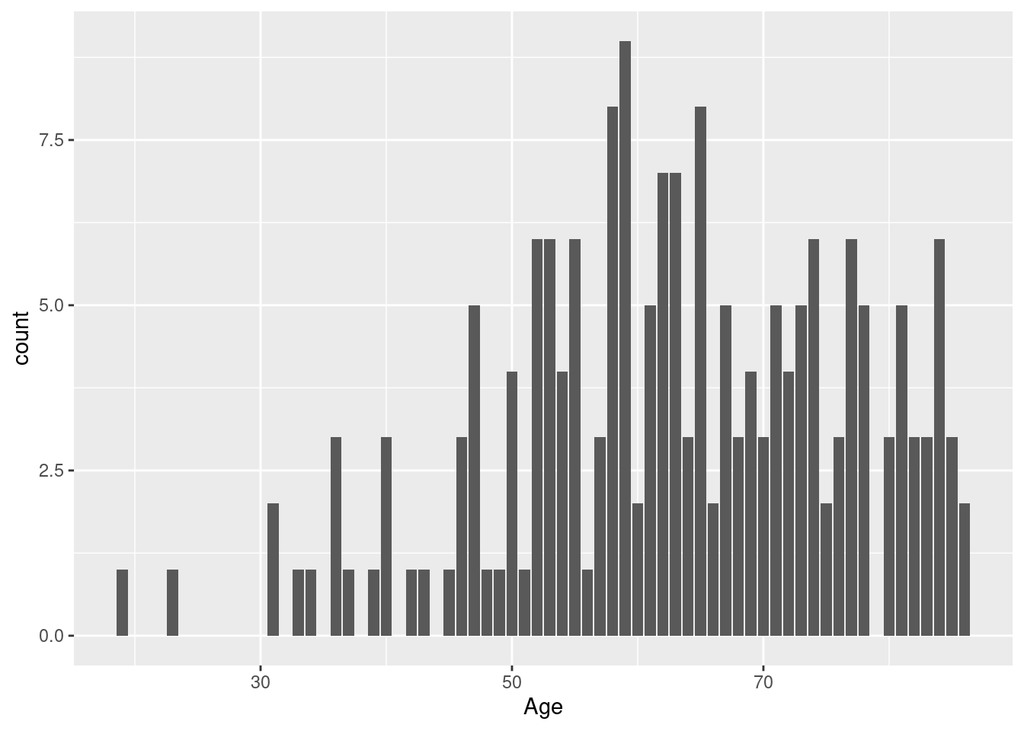

```r
study_admissions %>%
  ggplot() +
  geom_bar(mapping = aes(x = age)) +
  labs(x = "Age")
```

## Bar plot of gender

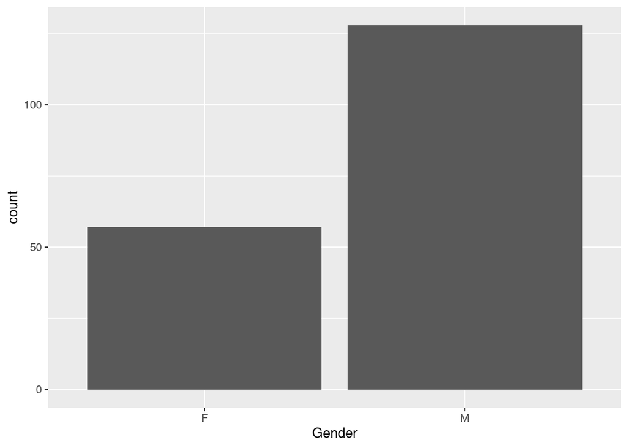

```r
study_admissions %>%
  ggplot() +
  geom_bar(mapping = aes(x = gender)) +
  labs(x = "Gender")
```

## Bar plot of ethnic_group

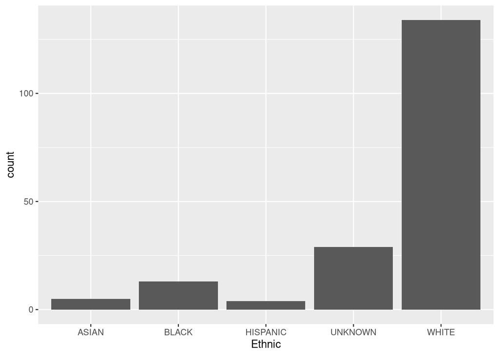

```r
study_admissions %>%
  ggplot() +
  geom_bar(mapping = aes(x = ethnic_group)) +
  labs(x = "Ethnic")
```

## Bar plot of admission location

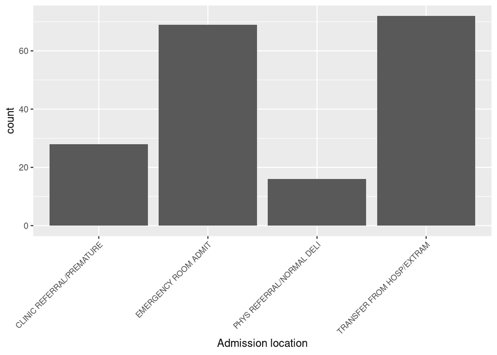

```r
study_admissions %>%
  ggplot() +
  geom_bar(mapping = aes(x = admission_location)) +
  labs(x = "Admission location") +
  theme(axis.text.x = element_text(size  = 8,
                                   angle = 45,
                                   hjust = 1,
                                   vjust = 1))
```

## Bar plot of drug severity

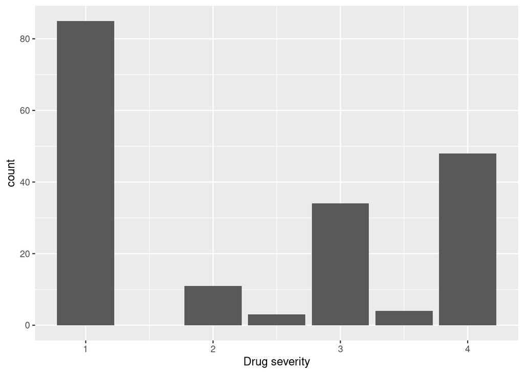

```r
study_admissions %>%
  ggplot() +
  geom_bar(mapping = aes(x = drg_severity)) +
  labs(x = "Drug severity")
```

# Analytics

## Logistic Regression

We first use logistic regression method to analysis the mortality rate of Cardiac Arrest in 30 days.

Split data to train set and test set. Then build the model.

```r
studyad<- study_admissions %>%
   mutate(livedeath = ifelse(is.na(death) == FALSE, 1, 0))
model_df<-as.data.frame(studyad)
set.seed(123)
#split data in to 70% traing set and 30% test set
s <- sample(nrow(model_df), floor(nrow(model_df)*0.7), replace = F)
train <- model_df[s,]
test <- model_df[-s,]
mylogit <- glm(livedeath ~ age + gender + ethnic_group + admission_location
               + drg_severity, data = train, family = binomial, maxit = 10000)
#use logistic method to find minist AIC
step <- step(mylogit, direction ='both')
```

```
## Start:  AIC=81.39
## livedeath ~ age + gender + ethnic_group + admission_location +
##     drg_severity
##
##                      Df Deviance    AIC
## - ethnic_group        4   62.798 76.798
## - admission_location  3   62.745 78.745
## - age                 1   59.756 79.756
## - gender              1   61.323 81.323
## <none>                    59.387 81.387
## - drg_severity        1   63.174 83.174
##
## Step:  AIC=76.8
## livedeath ~ age + gender + admission_location + drg_severity
##
##                      Df Deviance    AIC
## - age                 1   62.964 74.964
## - admission_location  3   67.278 75.278
## <none>                    62.798 76.798
## - drg_severity        1   66.357 78.357
## - gender              1   68.123 80.123
## + ethnic_group        4   59.387 81.387
##
## Step:  AIC=74.96
## livedeath ~ gender + admission_location + drg_severity
##
##                      Df Deviance    AIC
## - admission_location  3   67.430 73.430
## <none>                    62.964 74.964
## - drg_severity        1   66.368 76.368
## + age                 1   62.798 76.798
## - gender              1   69.076 79.076
## + ethnic_group        4   59.756 79.756
##
## Step:  AIC=73.43
## livedeath ~ gender + drg_severity
##
##                      Df Deviance    AIC
## <none>                    67.430 73.430
## - drg_severity        1   69.734 73.734
## + admission_location  3   62.964 74.964
## + age                 1   67.278 75.278
## - gender              1   73.062 77.062
## + ethnic_group        4   63.141 77.141
```

```r
summary(step)
```

```
##
## Call:
## glm(formula = livedeath ~ gender + drg_severity, family = binomial,
##     data = train, maxit = 10000)
##
## Deviance Residuals:
##     Min       1Q   Median       3Q      Max
## -0.7901  -0.4731  -0.3230  -0.2232   2.2915
##
## Coefficients:
##              Estimate Std. Error z value Pr(>|z|)
## (Intercept)   -2.5102     0.8247  -3.044  0.00234 **
## genderM       -1.5462     0.6675  -2.316  0.02054 *
## drg_severity   0.3765     0.2554   1.474  0.14040
## ---
## Signif. codes:  0 '***' 0.001 '**' 0.01 '*' 0.05 '.' 0.1 ' ' 1
##
## (Dispersion parameter for binomial family taken to be 1)
##
##     Null deviance: 75.196  on 128  degrees of freedom
## Residual deviance: 67.430  on 126  degrees of freedom
## AIC: 73.43
##
## Number of Fisher Scoring iterations: 6
```

Testing: Evaluate model performance on the test data.

```r
install.packages("pROC")
library(pROC)
```

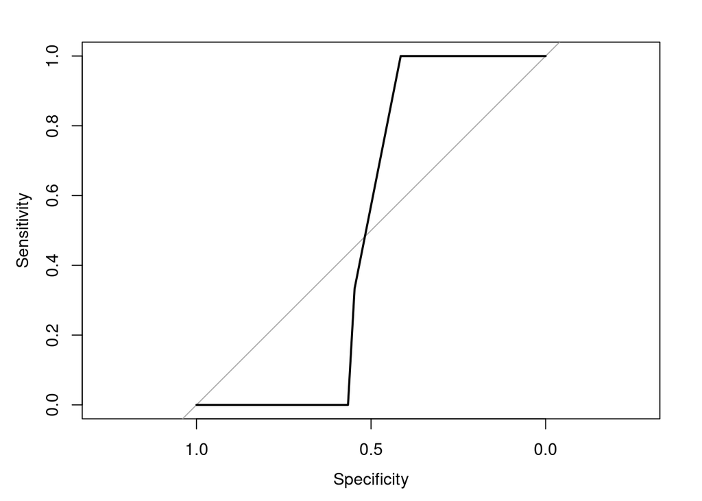

```r
install.packages("plotROC")
library(plotROC)
install.packages("DMwR")
library(DMwR)
pred <- predict(step, test, type = 'response')
fitted.r <- ifelse(pred >= 0.5, 1, 0)
accuracy <- table(fitted.r, test$livedeath)
roc <- roc(test$livedeath, pred)
plot(roc)
```

```r
roc
```

```
##
## Call:
## roc.default(response = test$livedeath, predictor = pred)
##
## Data: pred in 53 controls (test$livedeath 0) < 3 cases (test$livedeath 1).
## Area under the curve: 0.5063
```

The area under the curve is 0.5063. So the model built from this data set is not very accurate. 3 in 56 people will die for Cardiac Arrest in 30 days after being admitted to CCU. The 30-Day Mortality Rate of Cardiac Arrest Patients Admitted to CCU is about 5.4%.

## Neural network

I try 2 different methods of neural netwok.

First I use Keras package to specify and train models.

Aquire data:

```r
library(keras)
train_x <-train[,-9]
train_y<- train[ ,9]
test_x <- test[,-9]
test_y<- test[ ,9]
```

Prepare data:

Make scale entries to [0, 1]. Transform `trainx` and `testx` in to matrix.

```r
trainx <- train_x %>%
  mutate( age = age / max(age),
          gender = ifelse (gender == "F", 1, 0),
          drg_severity = drg_severity / max(drg_severity),
          ethnic_group = ifelse(ethnic_group == "WHITE", 1, ethnic_group),
          ethnic_group = ifelse(ethnic_group == "BLACK", 2, ethnic_group),
          ethnic_group = ifelse(ethnic_group == "UNKNOWN", 3, ethnic_group),
          ethnic_group = ifelse(ethnic_group == "ASIAN", 4, ethnic_group),
          ethnic_group = ifelse(ethnic_group == "HISPANIC", 5, ethnic_group),
          ethnic_group = as.numeric(ethnic_group) / 5,
          admission_location = ifelse(admission_location ==
                          "TRANSFER FROM HOSP/EXTRAM", 1, admission_location),
          admission_location = ifelse(admission_location ==
                          "CLINIC REFERRAL/PREMATURE", 2, admission_location),
          admission_location = ifelse(admission_location ==
                                "EMERGENCY ROOM ADMIT", 3, admission_location),
          admission_location = ifelse(admission_location ==
                           "PHYS REFERRAL/NORMAL DELI", 4, admission_location),
          admission_location = as.numeric(admission_location) / 4
         ) %>%
  select(-c(subject_id, hadm_id, death))
trainx <- as.matrix(trainx)

testx<-test_x %>%
  mutate( age = age / max(age),
          gender = ifelse (gender == "F", 1, 0),
          drg_severity = drg_severity / max(drg_severity),
          ethnic_group = ifelse(ethnic_group == "WHITE", 1, ethnic_group),
          ethnic_group = ifelse(ethnic_group == "BLACK", 2, ethnic_group),
          ethnic_group = ifelse(ethnic_group == "UNKNOWN", 3, ethnic_group),
          ethnic_group = ifelse(ethnic_group == "ASIAN", 4, ethnic_group),
          ethnic_group = ifelse(ethnic_group == "HISPANIC", 5, ethnic_group),
          ethnic_group = as.numeric(ethnic_group) / 5,
          admission_location = ifelse(admission_location ==
                             "TRANSFER FROM HOSP/EXTRAM",1, admission_location),
          admission_location = ifelse(admission_location ==
                             "CLINIC REFERRAL/PREMATURE",2, admission_location),
          admission_location = ifelse(admission_location ==
                             "EMERGENCY ROOM ADMIT",3, admission_location),
          admission_location = ifelse(admission_location ==
                             "PHYS REFERRAL/NORMAL DELI",4, admission_location),
          admission_location = as.numeric(admission_location) / 4
         ) %>%
  select(-c(subject_id, hadm_id, death))
testx <- as.matrix(testx)
```

Encode $y$ as binary class matrix:

```r
train_y <- to_categorical(train_y, 2)
test_y <- to_categorical(test_y, 2)
```

Define a **sequential model** (a linear stack of layers) with 2 fully-connected hidden layers (256 and 128 neurons):

```r
model <- keras_model_sequential()
model %>%
  layer_dense(units = 256, activation = 'relu', input_shape = c(5)) %>%
  layer_dropout(rate = 0.4) %>%
  layer_dense(units = 128, activation = 'relu') %>%
  layer_dropout(rate = 0.3) %>%
  layer_dense(units = 2, activation = 'softmax')
summary(model)
```

```
## Model: "sequential"
## ________________________________________________________________________________
## Layer (type)                        Output Shape                    Param #
## ================================================================================
## dense (Dense)                       (None, 256)                     1536
## ________________________________________________________________________________
## dropout (Dropout)                   (None, 256)                     0
## ________________________________________________________________________________
## dense_1 (Dense)                     (None, 128)                     32896
## ________________________________________________________________________________
## dropout_1 (Dropout)                 (None, 128)                     0
## ________________________________________________________________________________
## dense_2 (Dense)                     (None, 2)                       258
## ================================================================================
## Total params: 34,690
## Trainable params: 34,690
## Non-trainable params: 0
## ________________________________________________________________________________
```

Compile the model with appropriate loss function, optimizer, and metrics:

```r
model %>% compile(
  loss = 'categorical_crossentropy',
  optimizer = optimizer_rmsprop(),
  metrics = c('accuracy')
)
```

Training and validation:

```r
system.time({
history <- model %>% fit(
  trainx, train_y,
  epochs = 30, batch_size = 128,
  validation_split = 0.2
)
})
```

```
##    user  system elapsed
##   3.574   0.073   4.122
```

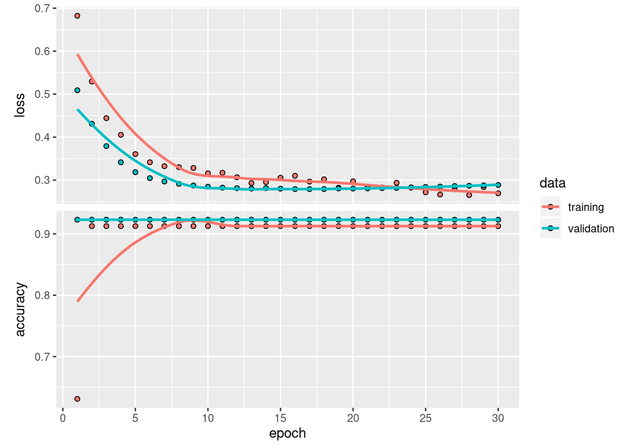

```r
plot(history)
```

Testing: Evaluate model performance on the test data:

```r
model %>% evaluate(testx, test_y)
```

```
## $loss
## [1] 0.2353048
##
## $accuracy
## [1] 0.9464286
```

Generate predictions on new data:

```r
predict <- model %>% predict_classes(testx)
mean(predict)
```

```
## [1] 0
```

The accuracy is about 94.6%. The 30-Day Mortality Rate of Cardiac Arrest Patients Admitted to CCU is about 5.4%.

Then I try another method with `DMwR` package and nnet function:

```r
install.packages("DMwR")
library(lattice)
library(grid)
library(DMwR)
library(nnet)
```

```r
live.nn<-nnet(livedeath ~ age + gender + ethnic_group + admission_location +
                drg_severity, data = train, size = 5, decay = 5e-4, maxit = 270)
summary(live.nn)
```

```
## a 10-5-1 network with 61 weights
## options were - decay=5e-04
##   b->h1  i1->h1  i2->h1  i3->h1  i4->h1  i5->h1  i6->h1  i7->h1  i8->h1  i9->h1
##  -11.35    0.12   -1.19    0.56   -4.86   -3.66   -3.35    5.21   -0.22    5.53
## i10->h1
##    0.91
##   b->h2  i1->h2  i2->h2  i3->h2  i4->h2  i5->h2  i6->h2  i7->h2  i8->h2  i9->h2
##   -0.01   -0.35   -0.01    0.00    0.00    0.01    0.00    0.00    0.00    0.00
## i10->h2
##   -0.02
##   b->h3  i1->h3  i2->h3  i3->h3  i4->h3  i5->h3  i6->h3  i7->h3  i8->h3  i9->h3
##    0.49   -0.36    0.50   -0.11   -0.02    0.90   -0.26   -0.14    0.00   -0.24
## i10->h3
##    2.27
##   b->h4  i1->h4  i2->h4  i3->h4  i4->h4  i5->h4  i6->h4  i7->h4  i8->h4  i9->h4
##   -0.03   -0.68   -0.05    0.01    0.00   -0.04   -0.01    0.00    0.00    0.00
## i10->h4
##   -0.17
##   b->h5  i1->h5  i2->h5  i3->h5  i4->h5  i5->h5  i6->h5  i7->h5  i8->h5  i9->h5
##    0.00   -0.28   -0.01    0.00   -0.01   -0.01    0.00   -0.01    0.01   -0.01
## i10->h5
##   -0.03
##   b->o  h1->o  h2->o  h3->o  h4->o  h5->o
##  -5.58   5.91  -0.26   8.35  -0.21  -0.24
```

Evaluate model performance on the test data:

```r
install.packages("pROC")
```

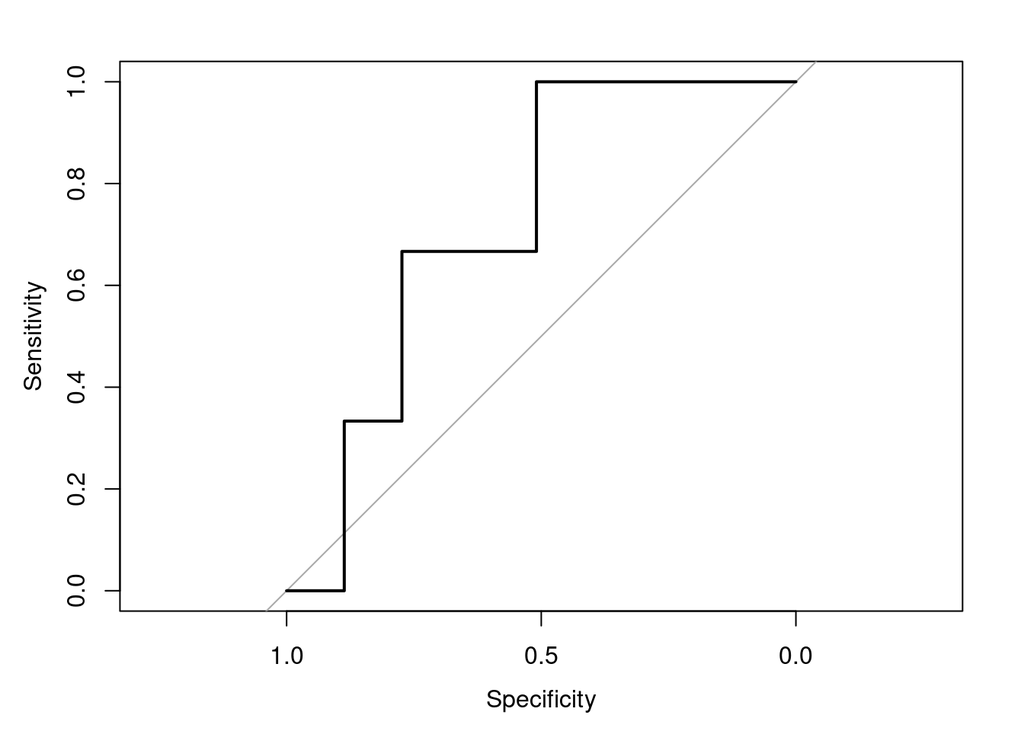

```r
library(pROC)
install.packages("plotROC")
library(plotROC)
install.packages("DMwR")
library(DMwR)
pred2 <- predict(live.nn, test)
fitted.r2 <- ifelse(pred2 >= 0.5, 1, 0)
accuracy2 <- table(fitted.r2, test$livedeath)
roc2 <- roc(test$livedeath, pred2)
plot(roc2)
```

```r
roc2
```

```
##
## Call:
## roc.default(response = test$livedeath, predictor = pred2)
##
## Data: pred2 in 53 controls (test$livedeath 0) < 3 cases (test$livedeath 1).
## Area under the curve: 0.7233
```

3 in 56 people will die for Cardiac Arrest in 30 days after being admitted to CCU. The 30-Day Mortality Rate of Cardiac Arrest Patients Admitted to CCU is about 5.4%.

Plot the neural:

```r
install.packages("reshape")
library(reshape)
library(nnet)
library(devtools)
library(reshape2)
```

```r
source_url('https://gist.githubusercontent.com/Peque/41a9e20d6687f2f3108d/raw/85e14f3a292e126f1454864427e3a189c2fe33f3/nnet_plot_update.r')
```

```
## SHA-1 hash of file is bf3c7b8ac910823b729e3ce73bb6ab5e6955ad3d
```

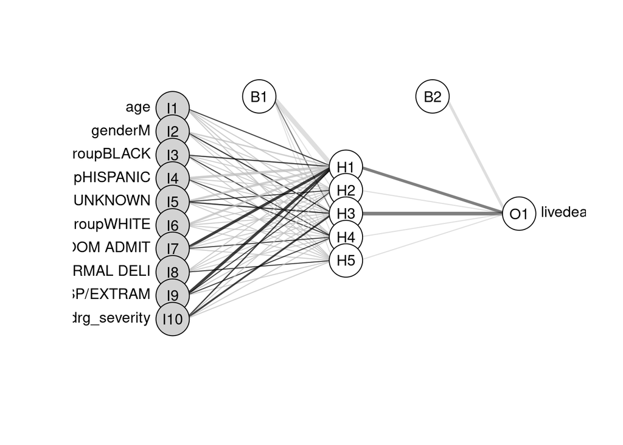

```r
plot.nnet(live.nn, alpha.val = 0.5, circle.col = list('lightgray', 'white'),
          bord.col = 'black')
```

# Close the connection to a database

Close the connection:

```r
dbDisconnect(con)
```

```
## [1] TRUE
```

# Conclusions